# US Income

Danny Kennen

2025-04-06

*Purpose*: We’ve been learning how to quantify uncertainty in estimates through the exercises; now its time to put those skills to use studying real data. In this challenge we’ll use concepts like confidence intervals to help us make sense of census data.

*Reading*: - [Using ACS Estimates and Margin of Error](https://www.census.gov/data/academy/webinars/2020/calculating-margins-of-error-acs.html) (Optional, see the PDF on the page) - [Patterns and Causes of Uncertainty in the American Community Survey](https://www.sciencedirect.com/science/article/pii/S0143622813002518?casa_token=VddzQ1-spHMAAAAA:FTq92LXgiPVloJUVjnHs8Ma1HwvPigisAYtzfqaGbbRRwoknNq56Y2IzszmGgIGH4JAPzQN0) (Optional, particularly the *Uncertainty in surveys* section under the Introduction.)

# Grading Rubric

Unlike exercises, **challenges will be graded**. The following rubrics define how you will be graded, both on an individual and team basis.

## Individual

| Category | Needs Improvement | Satisfactory |
| --- | --- | --- |
| Effort | Some task **q**’s left unattempted | All task **q**’s attempted |
| Observed | Did not document observations, or observations incorrect | Documented correct observations based on analysis |
| Supported | Some observations not clearly supported by analysis | All observations clearly supported by analysis (table, graph, etc.) |
| Assessed | Observations include claims not supported by the data, or reflect a level of certainty not warranted by the data | Observations are appropriately qualified by the quality & relevance of the data and (in)conclusiveness of the support |
| Specified | Uses the phrase “more data are necessary” without clarification | Any statement that “more data are necessary” specifies which *specific* data are needed to answer what *specific* question |
| Code Styled | Violations of the [style guide](https://style.tidyverse.org/) hinder readability | Code sufficiently close to the [style guide](https://style.tidyverse.org/) |

## Submission

Make sure to commit both the challenge report (`report.md` file) and supporting files (`report_files/` folder) when you are done! Then submit a link to Canvas. **Your Challenge submission is not complete without all files uploaded to GitHub.**

# Setup

```r
library(tidyverse)
```

### **q1** Load the population data from c06; simply replace `filename_pop` below.

```r
## TODO: Give the filename for your copy of Table B01003
filename_pop <- "./data/ACSDT5Y2018.B01003-Data.csv"

## NOTE: No need to edit
df_pop <-
  read_csv(
    filename_pop,
    skip = 1,
  ) %>%
  rename(
    population_estimate = `Estimate!!Total`
  )
```

```
## ──────────────────────────────────────────────────────── Delimiter: "," chr
## (3): Geography, Geographic Area Name, Margin of Error!!Total dbl (1):
## Estimate!!Total lgl (1): ...5
```

```r
df_pop
```

```
## # A tibble: 3,220 × 5
##    Geography   `Geographic Area Name` population_estimate Margin of Error!!Tot…¹
##    <chr>       <chr>                                <dbl> <chr>
##  1 0500000US0… Autauga County, Alaba…               55200 *****
##  2 0500000US0… Baldwin County, Alaba…              208107 *****
##  3 0500000US0… Barbour County, Alaba…               25782 *****
##  4 0500000US0… Bibb County, Alabama                 22527 *****
##  5 0500000US0… Blount County, Alabama               57645 *****
##  6 0500000US0… Bullock County, Alaba…               10352 *****
##  7 0500000US0… Butler County, Alabama               20025 *****
##  8 0500000US0… Calhoun County, Alaba…              115098 *****
##  9 0500000US0… Chambers County, Alab…               33826 *****
## 10 0500000US0… Cherokee County, Alab…               25853 *****
## # ℹ 3,210 more rows
## # ℹ abbreviated name: ¹`Margin of Error!!Total`
## # ℹ 1 more variable: ...5 <lgl>
```

You might wonder why the `Margin of Error` in the population estimates is listed as `*****`. From the documentation (PDF link) for the ACS:

> If the margin of error is displayed as ‘*****’ (five asterisks), the estimate has been controlled to be equal to a fixed value and so it has no sampling error. A standard error of zero should be used for these controlled estimates when completing calculations, such as those in the following section.

This means that for cases listed as `*****` the US Census Bureau recommends treating the margin of error (and thus standard error) as zero.

### **q2** Obtain median income data from the Census Bureau:

- `Filter > Topics > Income and Poverty > Income and Poverty`
- `Filter > Geography > County > All counties in United States`
- Look for `Median Income in the Past 12 Months` (Table S1903)
- Download the 2018 5-year ACS estimates; save to your `data` folder and add the filename below.

```r
## TODO: Give the filename for your copy of Table S1903
filename_income <- "./data/ACSST5Y2018.S1903-Data.csv"
## NOTE: No need to edit
df_income <-
  read_csv(filename_income, skip = 1)
df_income
```

```
## # A tibble: 3,220 × 243
##    Geography      `Geographic Area Name`   Estimate!!Number!!HOUSEHOLD INCOME …¹
##    <chr>          <chr>                                                    <dbl>
##  1 0500000US01001 Autauga County, Alabama                                  21115
##  2 0500000US01003 Baldwin County, Alabama                                  78622
##  3 0500000US01005 Barbour County, Alabama                                   9186
##  4 0500000US01007 Bibb County, Alabama                                      6840
##  5 0500000US01009 Blount County, Alabama                                   20600
##  6 0500000US01011 Bullock County, Alabama                                   3609
##  7 0500000US01013 Butler County, Alabama                                    6708
##  8 0500000US01015 Calhoun County, Alabama                                  45033
##  9 0500000US01017 Chambers County, Alabama                                 13516
## 10 0500000US01019 Cherokee County, Alabama                                 10606
## # ℹ 3,210 more rows
## # ℹ abbreviated name:
## #   ¹`Estimate!!Number!!HOUSEHOLD INCOME BY RACE AND HISPANIC OR LATINO ORIGIN OF HOUSEHOLDER!!Households`
## # ℹ 240 more variables:
## #   `Margin of Error!!Number MOE!!HOUSEHOLD INCOME BY RACE AND HISPANIC OR LATINO ORIGIN OF HOUSEHOLDER!!Households` <dbl>,
## #   `Estimate!!Number!!HOUSEHOLD INCOME BY RACE AND HISPANIC OR LATINO ORIGIN OF HOUSEHOLDER!!Households!!One race--!!White` <dbl>,
## #   `Margin of Error!!Number MOE!!HOUSEHOLD INCOME BY RACE AND HISPANIC OR LATINO ORIGIN OF HOUSEHOLDER!!Households!!One race--!!White` <dbl>, …
```

Use the following test to check that you downloaded the correct file:

```r
## NOTE: No need to edit, use to check you got the right file.
assertthat::assert_that(
  df_income %>%
    filter(Geography == "0500000US01001") %>%
    pull(`Estimate!!Percent Distribution!!FAMILY INCOME BY FAMILY SIZE!!2-person families`)
  == 45.6
)
```

```
## [1] TRUE
```

```r
print("Well done!")
```

```
## [1] "Well done!"
```

This dataset is in desperate need of some *tidying*. To simplify the task, we’ll start by considering the `\\d-person families` columns first.

### **q3** Tidy the `df_income` dataset by completing the code below. Pivot and rename the columns to arrive at the column names `id, geographic_area_name, category, income_estimate, income_moe`.

*Hint*: You can do this in a single pivot using the `".value"` argument and a `names_pattern` using capture groups `"()"`. Remember that you can use an OR operator `|` in a regex to allow for multiple possibilities in a capture group, for example `"(Estimate|Margin of Error)"`.

```r
df_q3 <-
  df_income %>%
  select(
    Geography,
    `Geographic Area Name`,
    contains("FAMILY INCOME BY FAMILY SIZE") & contains("Median income") & !contains("Annotation")
  ) %>%
  mutate(across(contains("Median income"), ~ suppressWarnings(as.numeric(.)))) %>%
  pivot_longer(
    cols = contains("FAMILY INCOME BY FAMILY SIZE"),
    names_to = c(".value", "category"),
    names_pattern = "(Estimate|Margin of Error)!!Median income \\(dollars\\)(?: MOE)?!!FAMILY INCOME BY FAMILY SIZE!!(.*)"
  ) %>%
  rename(
    geographic_area_name = `Geographic Area Name`,
    income_estimate = Estimate,
    income_moe = `Margin of Error`
  ) %>%
  glimpse()
```

```
## Rows: 19,320
## Columns: 5
## $ Geography            <chr> "0500000US01001", "0500000US01001", "0500000US010…
## $ geographic_area_name <chr> "Autauga County, Alabama", "Autauga County, Alaba…
## $ category             <chr> "2-person families", "3-person families", "4-pers…
## $ income_estimate      <dbl> 64947, 80172, 85455, 88601, 103787, 135083, 63975…
## $ income_moe           <dbl> 6663, 14181, 10692, 20739, 12387, 73304, 2297, 88…
```

Use the following tests to check your work:

```r
## NOTE: No need to edit
assertthat::assert_that(setequal(
  names(df_q3),
  c("Geography", "geographic_area_name", "category", "income_estimate", "income_moe")
))
```

```
## [1] TRUE
```

```r
assertthat::assert_that(
  df_q3 %>%
    filter(Geography == "0500000US01001", category == "2-person families") %>%
    pull(income_moe)
  == 6663
)
```

```
## [1] TRUE
```

```r
print("Nice!")
```

```
## [1] "Nice!"
```

The data gives finite values for the Margin of Error, which is closely related to the Standard Error. The Census Bureau documentation gives the following relationship between Margin of Error and Standard Error:

$$\text{MOE} = 1.645 \times
\text{SE}.$$

### **q4** Convert the margin of error to standard error. Additionally, compute a 99% confidence interval on income, and normalize the standard error to `income_CV = income_SE / income_estimate`. Provide these columns with the names `income_SE, income_lo, income_hi, income_CV`.

```r
df_q4 <- df_q3 %>%
  mutate(
    income_SE = income_moe / 1.645,
    income_lo = income_estimate - 2.576 * income_SE,
    income_hi = income_estimate + 2.576 * income_SE,
    income_CV = income_SE / income_estimate
  )

glimpse(df_q4)
```

```
## Rows: 19,320
## Columns: 9
## $ Geography            <chr> "0500000US01001", "0500000US01001", "0500000US010…
## $ geographic_area_name <chr> "Autauga County, Alabama", "Autauga County, Alaba…
## $ category             <chr> "2-person families", "3-person families", "4-pers…
## $ income_estimate      <dbl> 64947, 80172, 85455, 88601, 103787, 135083, 63975…
## $ income_moe           <dbl> 6663, 14181, 10692, 20739, 12387, 73304, 2297, 88…
## $ income_SE            <dbl> 4050.456, 8620.669, 6499.696, 12607.295, 7530.091…
## $ income_lo            <dbl> 54513.026, 57965.157, 68711.783, 56124.609, 84389…
## $ income_hi            <dbl> 75380.97, 102378.84, 102198.22, 121077.39, 123184…
## $ income_CV            <dbl> 0.06236556, 0.10752718, 0.07605987, 0.14229292, 0…
```

Use the following tests to check your work:

```r
## NOTE: No need to edit
assertthat::assert_that(setequal(
  names(df_q4),
  c("Geography", "geographic_area_name", "category", "income_estimate", "income_moe",
    "income_SE", "income_lo", "income_hi", "income_CV")
))
```

```
## [1] TRUE
```

```r
assertthat::assert_that(
  abs(
    df_q4 %>%
    filter(Geography == "0500000US01001", category == "2-person families") %>%
    pull(income_SE) - 4050.456
  ) / 4050.456 < 1e-3
)
```

```
## [1] TRUE
```

```r
assertthat::assert_that(
  abs(
    df_q4 %>%
    filter(Geography == "0500000US01001", category == "2-person families") %>%
    pull(income_lo) - 54513.72
  ) / 54513.72 < 1e-3
)
```

```
## [1] TRUE
```

```r
assertthat::assert_that(
  abs(
    df_q4 %>%
    filter(Geography == "0500000US01001", category == "2-person families") %>%
    pull(income_hi) - 75380.28
  ) / 75380.28 < 1e-3
)
```

```
## [1] TRUE
```

```r
assertthat::assert_that(
  abs(
    df_q4 %>%
    filter(Geography == "0500000US01001", category == "2-person families") %>%
    pull(income_CV) - 0.06236556
  ) / 0.06236556 < 1e-3
)
```

```
## [1] TRUE
```

```r
print("Nice!")
```

```
## [1] "Nice!"
```

One last wrangling step: We need to join the two datasets so we can compare population with income.

### **q5** Join `df_q4` and `df_pop`.

```r
## TODO: Join df_q4 and df_pop by the appropriate column
df_data <- merge(df_q4, df_pop, by = "Geography", all = FALSE)
```

# Analysis

We now have both estimates and confidence intervals for `\\d-person families`. Now we can compare cases with quantified uncertainties: Let’s practice!

### **q6** Study the following graph, making sure to note what you can *and can’t* conclude based on the estimates and confidence intervals. Document your observations below and answer the questions.

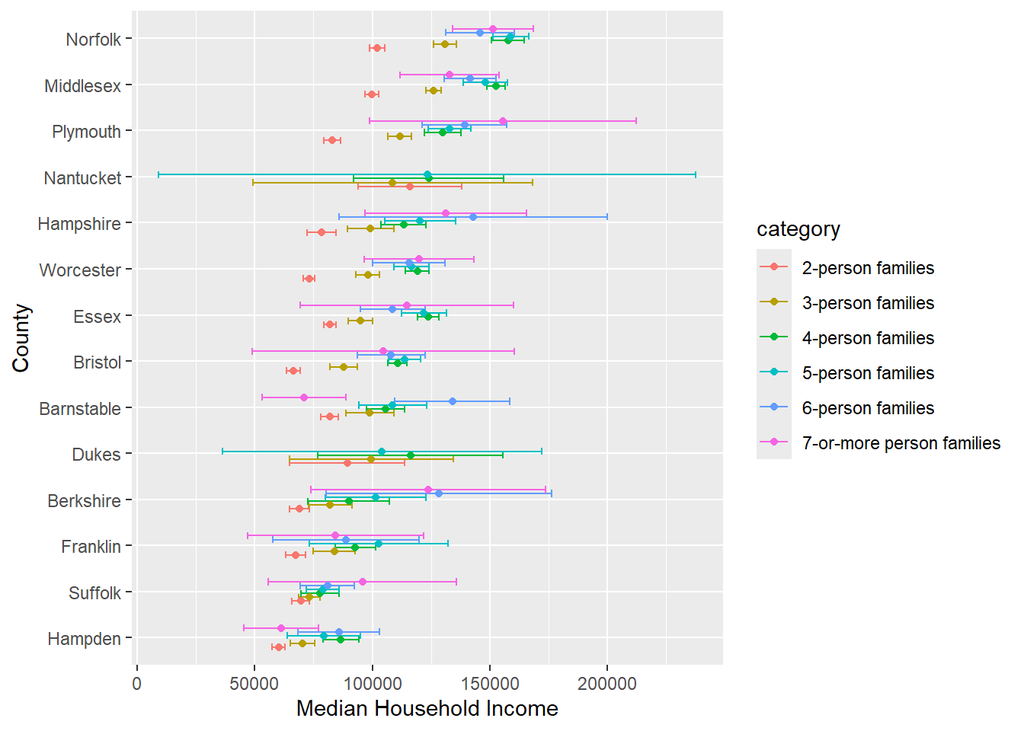

```r
## NOTE: No need to edit; run and inspect
wid <- 0.5

df_data %>%
  filter(str_detect(geographic_area_name, "Massachusetts")) %>%
  mutate(
    county = str_remove(geographic_area_name, " County,.*$"),
    county = fct_reorder(county, income_estimate)
  ) %>%

  ggplot(aes(county, income_estimate, color = category)) +
  geom_errorbar(
    aes(ymin = income_lo, ymax = income_hi),
    position = position_dodge(width = wid)
  ) +
  geom_point(position = position_dodge(width = wid)) +

  coord_flip() +
  labs(
    x = "County",
    y = "Median Household Income"
  )
```

**Observations**:

In the next task you’ll investigate the relationship between population and uncertainty.

### **q7** Plot the standard error against population for all counties. Create a visual that effectively highlights the trends in the data. Answer the questions under *observations* below.

*Hint*: Remember that standard error is a function of *both* variability (e.g. variance) and sample size.

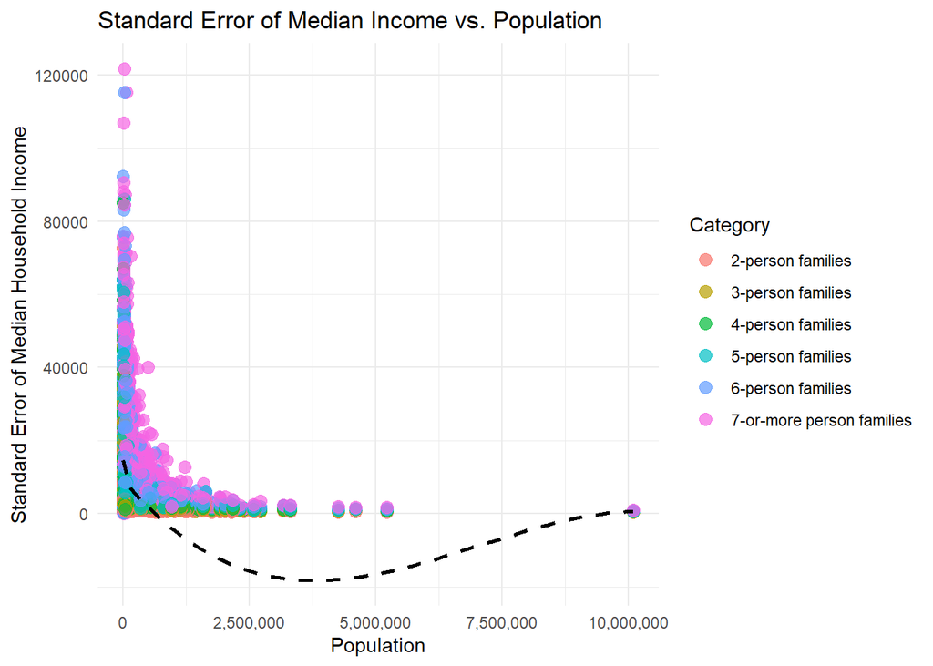

```r
df_data %>%
  ggplot(aes(x = population_estimate, y = income_SE, color = category)) +
  geom_point(alpha = 0.7, size = 3) +
  geom_smooth(method = "loess", se = FALSE, color = "black", linetype = "dashed") +
  scale_x_continuous(labels = scales::comma) +
  labs(
    title = "Standard Error of Median Income vs. Population",
    x = "Population",
    y = "Standard Error of Median Household Income",
    color = "Category"
  ) +
  theme_minimal()
```

**Observations**:

- What *overall* trend do you see between `SE` and population? Why might this trend exist?
  - The lower the population the higher the SE, this is likely because individuals will have more of an effect on the median income when the population is smaller, so individual incomes skew the median more.
- What does this *overall* trend tell you about the relative ease of studying small vs large counties?
  - It is harder to get accurate studies in small counties because individuals skew the data more and sample sizes are more limited.

# Going Further

Now it’s your turn! You have income data for every county in the United States: Pose your own question and try to answer it with the data.

### **q8** Pose your own question about the data. Create a visualization (or table) here, and document your observations.

My Question is what does the median income spread look like in rural (less than 50,000) verses urban places?

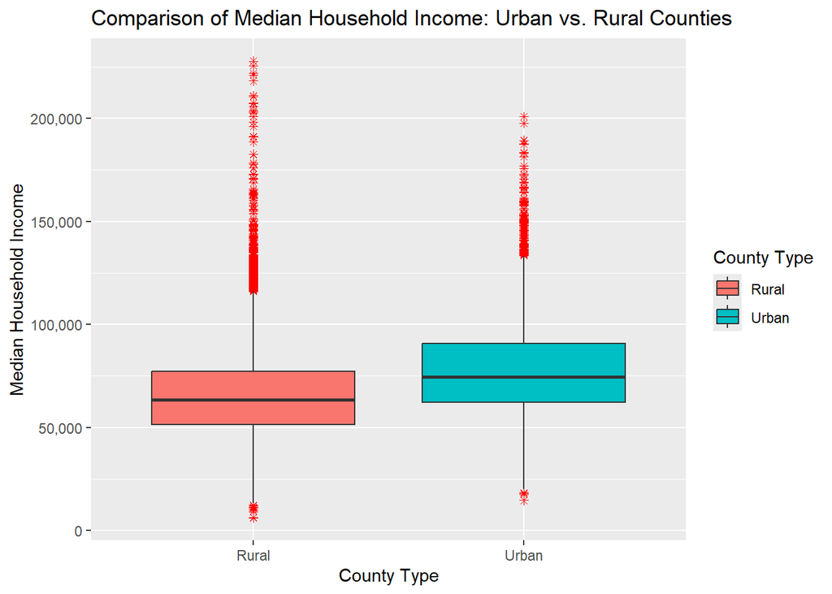

```r
## TODO: Pose and answer your own question about the data
df_data <- df_data %>%
  mutate(
    county_type = ifelse(population_estimate > 50000, "Urban", "Rural")
  )
df_data %>%
  ggplot(aes(x = county_type, y = income_estimate, fill = county_type)) +
  geom_boxplot(outlier.colour = "red", outlier.shape = 8) +
  scale_y_continuous(labels = scales::comma) +
  labs(
    title = "Comparison of Median Household Income: Urban vs. Rural Counties",
    x = "County Type",
    y = "Median Household Income",
    fill = "County Type"
  )
```

**Observations**:

Ideas:

- Compare trends across counties that are relevant to you; e.g. places you’ve lived, places you’ve been, places in the US that are interesting to you.
- In q3 we tidied the median `\\d-person families` columns only.
  - Tidy the other median columns to learn about other people groups.
  - Tidy the percentage columns to learn about how many households of each category are in each county.
- Your own idea!

# References

[1] Spielman SE, Folch DC, Nagle NN (2014) Patterns and causes of uncertainty in the American Community Survey. Applied Geography 46: 147–157. pmid:25404783 [link](https://www.sciencedirect.com/science/article/pii/S0143622813002518?casa_token=VddzQ1-spHMAAAAA:FTq92LXgiPVloJUVjnHs8Ma1HwvPigisAYtzfqaGbbRRwoknNqZ6Y2IzszmGgIGH4JAPzQN0)